# DATA SCIENCE LATAM

UN ESPACIO PARA NUNCA PARAR DE APRENDER!!

Francisco Zambrano Cruz. Mayo 2020.

[figure not shown]

# Pre Procesamiento datos con CARET

```r
library(caret)
```

## 1. Creando Variables Dummy

**Caret** incluye varias funciones para preprocesar los datos del predictor. Los datos de las variables dummy son numéricos (es decir, factores que han sido convertidos a través de variables dummy con las funciones **model.matrix / dummyVars**).

**etitanic** incluye dos factores: pclass(clase de pasajero, con niveles 1º, 2º, 3º) y sex(con niveles femenino, masculino).

```r
#Cargamos la libreria y el set de datos etitanic
library(earth)
data(etitanic)
head(etitanic)
```

| pclass | survived | sex | age | sibsp | parch |
| --- | --- | --- | --- | --- | --- |
| 1st | 1 | female | 29.0000 | 0 | 0 |
| 1st | 1 | male | 0.9167 | 1 | 2 |
| 1st | 0 | female | 2.0000 | 1 | 2 |
| 1st | 0 | male | 30.0000 | 1 | 2 |
| 1st | 0 | female | 25.0000 | 1 | 2 |
| 1st | 1 | male | 48.0000 | 0 | 0 |

```r
#La función base R model.matrix generaría las variables dummys:

head(model.matrix(survived ~ ., data = etitanic))
```

| (Intercept) | pclass2nd | pclass3rd | sexmale | age | sibsp | parch |
| --- | --- | --- | --- | --- | --- | --- |
| 1 | 0 | 0 | 0 | 29.0000 | 0 | 0 |
| 1 | 0 | 0 | 1 | 0.9167 | 1 | 2 |
| 1 | 0 | 0 | 0 | 2.0000 | 1 | 2 |
| 1 | 0 | 0 | 1 | 30.0000 | 1 | 2 |
| 1 | 0 | 0 | 0 | 25.0000 | 1 | 2 |
| 1 | 0 | 0 | 1 | 48.0000 | 0 | 0 |

```r
#Utilzando la función dummyVars

dummies <- dummyVars(survived ~ ., data = etitanic)

head(dummies,10)
```

[output not shown]

```r
head(predict(dummies, newdata = etitanic))
```

| pclass.1st | pclass.2nd | pclass.3rd | sex.female | sex.male | age | sibsp | parch |
| --- | --- | --- | --- | --- | --- | --- | --- |
| 1 | 0 | 0 | 1 | 0 | 29.0000 | 0 | 0 |
| 1 | 0 | 0 | 0 | 1 | 0.9167 | 1 | 2 |
| 1 | 0 | 0 | 1 | 0 | 2.0000 | 1 | 2 |
| 1 | 0 | 0 | 0 | 1 | 30.0000 | 1 | 2 |
| 1 | 0 | 0 | 1 | 0 | 25.0000 | 1 | 2 |
| 1 | 0 | 0 | 0 | 1 | 48.0000 | 0 | 0 |

## 2. Predictores de varianza cero y cercano a cero

A veces hay predictores que solo tienen un único valor (es decir, un "predictor de varianza cero"). Para muchos modelos (excluyendo los modelos basados en árboles), esto puede hacer que el modelo se bloquee o que el ajuste sea inestable.

Del mismo modo, hay predictores que solo tiene pocos valores únicos que ocurren con frecuencias muy bajas.

```r
# este es un ejemplo de una variable nR11 con pocos valores unicos y que están altamente desequilibrados:

data(mdrr)
head(mdrrDescr)
```

|  | MW | AMW | Sv | Se | Sp | Ss | Mv | Me | Mp | Ms | ... | G.O..Br. | G.O..I. | G.S..S. | G.S..F. | G.S..Cl. | G.F..F. | G.F..Cl. | G.Cl..Cl. | G.Cl..Br. | G.I..I. |
| --- | --- | --- | --- | --- | --- | --- | --- | --- | --- | --- | --- | --- | --- | --- | --- | --- | --- | --- | --- | --- | --- |
| METHOPROMAZINE | 314.49 | 7.15 | 27.56 | 43.50 | 29.69 | 42.17 | 0.63 | 0.99 | 0.67 | 1.92 | ... | 0 | 0 | 0 | 0 | 0 | 0 | 0 | 0 | 0 | 0 |
| ACEPROMAZINE | 326.50 | 7.26 | 28.56 | 44.50 | 30.69 | 47.33 | 0.63 | 0.99 | 0.68 | 2.06 | ... | 0 | 0 | 0 | 0 | 0 | 0 | 0 | 0 | 0 | 0 |
| TRIMEPRAZINE | 298.49 | 6.94 | 27.05 | 42.17 | 29.24 | 38.83 | 0.63 | 0.98 | 0.68 | 1.85 | ... | 0 | 0 | 0 | 0 | 0 | 0 | 0 | 0 | 0 | 0 |
| PROMETHAZINE | 284.46 | 7.11 | 25.46 | 39.28 | 27.48 | 37.33 | 0.64 | 0.98 | 0.69 | 1.87 | ... | 0 | 0 | 0 | 0 | 0 | 0 | 0 | 0 | 0 | 0 |
| ACEPROMETAZINE | 326.50 | 7.26 | 28.56 | 44.50 | 30.69 | 47.67 | 0.63 | 0.99 | 0.68 | 2.07 | ... | 0 | 0 | 0 | 0 | 0 | 0 | 0 | 0 | 0 | 0 |
| PYRATHIAZINE | 296.47 | 7.23 | 26.46 | 40.28 | 28.48 | 37.50 | 0.65 | 0.98 | 0.69 | 1.79 | ... | 0 | 0 | 0 | 0 | 0 | 0 | 0 | 0 | 0 | 0 |

```r
data.frame(table(mdrrDescr$nR11))
```

| Var1 | Freq |
| --- | --- |
| 0 | 501 |
| 1 | 4 |
| 2 | 23 |

Estos predictores pueden convertirse en predictores de varianza cero cuando los datos se dividen en submuestras de **validación cruzada / bootstrap** o que algunas muestras pueden tener una influencia indebida en el modelo. Es posible que estos predictores de "varianza cercana a cero" deban identificarse y eliminarse antes del modelado.

Para identificar estos tipos de predictores, se pueden calcular las siguientes dos métricas:

1. División del valor más frecuente sobre el segundo valor más frecuente (**"frequency ratio"**), que sería cercano a 1 para predictores equilibrados y muy grande para datos altamente desequilibrados.
2. El **"percent of unique values"** es el número de valores únicos dividido para el número total de muestras (multiplicado por 100) que se aproxima a 0 a medida que aumenta la granularidad de los datos.

La función **nearZeroVar** se puede usar para identificar variables de varianza cercana a cero (el argumento **saveMetrics** se puede usar para mostrar los detalles y, por lo general, está predeterminado en FALSE):

```r
nzv <- nearZeroVar(mdrrDescr, saveMetrics= TRUE)

#para conocer los valores near Zero Var:
nzv[nzv$nzv,]
```

|  | freqRatio | percentUnique | zeroVar | nzv |
| --- | --- | --- | --- | --- |
| nTB | 23.00000 | 0.3787879 | FALSE | TRUE |
| nBR | 131.00000 | 0.3787879 | FALSE | TRUE |
| nI | 527.00000 | 0.3787879 | FALSE | TRUE |
| nR03 | 527.00000 | 0.3787879 | FALSE | TRUE |
| nR08 | 527.00000 | 0.3787879 | FALSE | TRUE |
| nR11 | 21.78261 | 0.5681818 | FALSE | TRUE |
| nR12 | 57.66667 | 0.3787879 | FALSE | TRUE |
| D.Dr03 | 527.00000 | 0.3787879 | FALSE | TRUE |
| D.Dr07 | 123.50000 | 5.8712121 | FALSE | TRUE |
| D.Dr08 | 527.00000 | 0.3787879 | FALSE | TRUE |
| D.Dr09 | 479.00000 | 9.4696970 | FALSE | TRUE |
| D.Dr11 | 125.25000 | 4.5454545 | FALSE | TRUE |
| D.Dr12 | 519.00000 | 1.8939394 | FALSE | TRUE |
| T.N..S. | 35.07692 | 5.4924242 | FALSE | TRUE |
| T.N..F. | 94.00000 | 6.0606061 | FALSE | TRUE |
| T.N..Cl. | 43.20000 | 7.1969697 | FALSE | TRUE |
| T.N..Br. | 262.00000 | 0.7575758 | FALSE | TRUE |
| T.N..I. | 527.00000 | 0.3787879 | FALSE | TRUE |
| T.O..S. | 80.50000 | 4.7348485 | FALSE | TRUE |
| T.O..F. | 68.00000 | 5.6818182 | FALSE | TRUE |
| T.O..Cl. | 50.22222 | 6.8181818 | FALSE | TRUE |
| T.O..Br. | 262.50000 | 0.5681818 | FALSE | TRUE |
| T.O..I. | 527.00000 | 0.3787879 | FALSE | TRUE |
| T.S..S. | 65.00000 | 0.3787879 | FALSE | TRUE |
| T.S..F. | 130.00000 | 0.9469697 | FALSE | TRUE |
| T.S..Cl. | 42.41667 | 1.5151515 | FALSE | TRUE |
| T.F..F. | 50.80000 | 2.0833333 | FALSE | TRUE |
| T.F..Cl. | 173.33333 | 1.3257576 | FALSE | TRUE |
| T.Cl..Cl. | 45.81818 | 2.4621212 | FALSE | TRUE |
| T.Cl..Br. | 527.00000 | 0.3787879 | FALSE | TRUE |
| T.I..I. | 527.00000 | 0.3787879 | FALSE | TRUE |
| G.N..Br. | 262.00000 | 0.7575758 | FALSE | TRUE |
| G.N..I. | 527.00000 | 0.3787879 | FALSE | TRUE |
| G.O..S. | 161.00000 | 7.1969697 | FALSE | TRUE |
| G.O..F. | 158.66667 | 8.7121212 | FALSE | TRUE |
| G.O..Br. | 262.50000 | 0.5681818 | FALSE | TRUE |
| G.O..I. | 527.00000 | 0.3787879 | FALSE | TRUE |
| G.S..S. | 260.00000 | 1.3257576 | FALSE | TRUE |
| G.S..F. | 260.00000 | 1.5151515 | FALSE | TRUE |
| G.S..Cl. | 169.66667 | 2.6515152 | FALSE | TRUE |
| G.F..F. | 101.60000 | 3.2196970 | FALSE | TRUE |
| G.F..Cl. | 520.00000 | 1.7045455 | FALSE | TRUE |
| G.Cl..Cl. | 168.00000 | 3.5984848 | FALSE | TRUE |
| G.Cl..Br. | 527.00000 | 0.3787879 | FALSE | TRUE |
| G.I..I. | 527.00000 | 0.3787879 | FALSE | TRUE |

```r
#para conocer los valores que no son near Zero Var:

nzv[-nzv$nzv,][1:10,]
```

|  | freqRatio | percentUnique | zeroVar | nzv |
| --- | --- | --- | --- | --- |
| AMW | 1.125000 | 42.613636 | FALSE | FALSE |
| Sv | 1.000000 | 82.954545 | FALSE | FALSE |
| Se | 1.250000 | 84.280303 | FALSE | FALSE |
| Sp | 1.250000 | 82.765152 | FALSE | FALSE |
| Ss | 1.000000 | 71.212121 | FALSE | FALSE |
| Mv | 1.084507 | 3.409091 | FALSE | FALSE |
| Me | 1.176471 | 1.704545 | FALSE | FALSE |
| Mp | 1.157143 | 3.787879 | FALSE | FALSE |
| Ms | 1.125000 | 18.560606 | FALSE | FALSE |
| nAT | 1.047619 | 13.636364 | FALSE | FALSE |

```r
#La dimensiones del set de datos mdrrDescr
dim(mdrrDescr)
```

1. 528

2. 342

```r
# Por defecto, nearZeroVar devolverá las posiciones de las variables marcadas como problemáticas.

nzv <- nearZeroVar(mdrrDescr)
nzv
```

1. 22

2. 31

3. 32

4. 34

5. 38

6. 41

7. 42

8. 259

9. 262

10. 263

11. 264

12. 266

13. 267

14. 270

15. 271

16. 272

17. 273

18. 274

19. 276

20. 277

21. 278

22. 279

23. 280

24. 281

25. 282

26. 283

27. 284

28. 285

29. 286

30. 287

31. 288

32. 327

33. 328

34. 330

35. 331

36. 333

37. 334

38. 335

39. 336

40. 337

41. 338

42. 339

43. 340

44. 341

45. 342

```r
filteredDescr <- mdrrDescr[, -nzv]
dim(filteredDescr)
```

1. 528

2. 297

El datset etitanic no tiene variables problematicas

```r
nzv2 <- nearZeroVar(etitanic, saveMetrics= TRUE)
nzv2
```

|  | freqRatio | percentUnique | zeroVar | nzv |
| --- | --- | --- | --- | --- |
| pclass | 1.764085 | 0.2868069 | FALSE | FALSE |
| survived | 1.449649 | 0.1912046 | FALSE | FALSE |
| sex | 1.695876 | 0.1912046 | FALSE | FALSE |
| age | 1.093023 | 9.3690249 | FALSE | FALSE |
| sibsp | 2.446429 | 0.6692161 | FALSE | FALSE |
| parch | 4.800000 | 0.6692161 | FALSE | FALSE |

## 3. Identificación de predictores correlacionados

Si bien hay algunos modelos que prosperan con predictores correlacionados (como pls), otros modelos pueden beneficiarse al reducir el nivel de correlación entre los predictores.

```r
#matriz de correlacion
descrCor <-  cor(filteredDescr)
head(descrCor)
```

|  | MW | AMW | Sv | Se | Sp | Ss | Mv | Me | Mp | Ms | ... | QXXp | QYYp | QZZp | G.N..N. | G.N..O. | G.N..S. | G.N..F. | G.N..Cl. | G.O..O. | G.O..Cl. |
| --- | --- | --- | --- | --- | --- | --- | --- | --- | --- | --- | --- | --- | --- | --- | --- | --- | --- | --- | --- | --- | --- |
| MW | 1.0000000 | 0.20967709 | 0.95188957 | 0.9286910 | 0.94737618 | 0.9298075 | -0.09082461 | 0.34587009 | -0.1052367 | 0.27981880 | ... | 0.65625211 | 0.69193631 | 0.77910978 | 0.3378901 | 0.54925352 | 0.12040609 | 0.2133348 | 0.2032267431 | 0.462790118 | 0.23218369 |
| AMW | 0.2096771 | 1.00000000 | -0.06801714 | -0.1545355 | -0.07976117 | 0.2447579 | 0.73701464 | 0.65696280 | 0.6836689 | 0.48300240 | ... | -0.07012325 | -0.07504988 | -0.09040239 | 0.0820371 | 0.04665133 | 0.22803052 | 0.2021923 | 0.5153135748 | -0.005732334 | 0.36383665 |
| Sv | 0.9518896 | -0.06801714 | 1.00000000 | 0.9853667 | 0.99899196 | 0.8563386 | -0.22831661 | 0.10947144 | -0.2254321 | 0.09517120 | ... | 0.68351602 | 0.72148548 | 0.82541415 | 0.2820395 | 0.47881599 | 0.05342510 | 0.1503352 | 0.0592438126 | 0.420550477 | 0.11628036 |
| Se | 0.9286910 | -0.15453552 | 0.98536665 | 1.0000000 | 0.98465186 | 0.8537654 | -0.37580835 | 0.13263700 | -0.3759322 | 0.12881552 | ... | 0.69651349 | 0.73548868 | 0.82497684 | 0.3141256 | 0.55050020 | 0.01998360 | 0.1268683 | 0.0007179174 | 0.483289557 | 0.07854104 |
| Sp | 0.9473762 | -0.07976117 | 0.99899196 | 0.9846519 | 1.00000000 | 0.8409921 | -0.23682236 | 0.08380525 | -0.2238575 | 0.07234055 | ... | 0.68316480 | 0.72093113 | 0.82875111 | 0.2699670 | 0.46428646 | 0.07163484 | 0.1364674 | 0.0589758231 | 0.412811131 | 0.11646273 |
| Ss | 0.9298075 | 0.24475788 | 0.85633860 | 0.8537654 | 0.84099210 | 1.0000000 | -0.11473060 | 0.54649645 | -0.1904525 | 0.57136972 | ... | 0.55729459 | 0.59328016 | 0.69971617 | 0.3009196 | 0.59638803 | 0.01699589 | 0.3548937 | 0.1153216202 | 0.524748224 | 0.18548243 |

```r
# upper.tri(descrCor) para obtener la parte triangular superior de la matriz
highCorr <- sum(abs(descrCor[upper.tri(descrCor)]) > .999)
highCorr
```

65

Para los datos anteriores, hay 65 variables que están casi perfectamente correlacionados (|correlación|> 0.999).

```r
# Descriptivo antes de elimniar las varibales correlacionas

descrCor <- cor(filteredDescr)
summary(descrCor[upper.tri(descrCor)])
```

```
    Min.  1st Qu.   Median     Mean  3rd Qu.     Max.
-0.99607 -0.05373  0.25006  0.26078  0.65527  1.00000
```

```r
#Se procede a eliminar las variables con correlaciones absolutas superiores a 0,75.

highlyCorDescr <- findCorrelation(descrCor, cutoff = .75)

filteredDescr <- filteredDescr[,-highlyCorDescr]
```

```r
# Descriptivo luego de eliminar las varibales correlacionas superiores a 0,75.
descrCor2 <- cor(filteredDescr)
summary(descrCor2[upper.tri(descrCor2)])
```

```
    Min.  1st Qu.   Median     Mean  3rd Qu.     Max.
-0.70728 -0.05378  0.04418  0.06692  0.18858  0.74458
```

## 4. Dependencias lineales

La función **findLinearCombos** utiliza la descomposición QR de una matriz para enumerar conjuntos de combinaciones lineales (si existen).

Por ejemplo, considere la siguiente matriz:

```r
ltfrDesign <- matrix(0, nrow=6, ncol=6)
ltfrDesign[,1] <- c(1, 1, 1, 1, 1, 1)
ltfrDesign[,2] <- c(1, 1, 1, 0, 0, 0)
ltfrDesign[,3] <- c(0, 0, 0, 1, 1, 1)
ltfrDesign[,4] <- c(1, 0, 0, 1, 0, 0)
ltfrDesign[,5] <- c(0, 1, 0, 0, 1, 0)
ltfrDesign[,6] <- c(0, 0, 1, 0, 0, 1)

ltfrDesign
```

| 1 | 1 | 0 | 1 | 0 | 0 |
| --- | --- | --- | --- | --- | --- |
| 1 | 1 | 0 | 0 | 1 | 0 |
| 1 | 1 | 0 | 0 | 0 | 1 |
| 1 | 0 | 1 | 1 | 0 | 0 |
| 1 | 0 | 1 | 0 | 1 | 0 |
| 1 | 0 | 1 | 0 | 0 | 1 |

Tenga en cuenta que la primera columna es la suma de las columnas dos y tres. Del mismo modo, la suma de las columnas cuatro, cinco y seis es la primera columna.

**findLinearCombos** devolverá una lista que enumera estas dependencias. Para cada combinación lineal, eliminará gradualmente las columnas de la matriz y probará para ver si las dependencias se han resuelto. findLinearCombos también devolverá un vector de posiciones de columna que se pueden eliminar para eliminar las dependencias lineales:

```r
comboInfo <- findLinearCombos(ltfrDesign)
comboInfo
```

**$linearCombos**

1. 1. 3

   2. 1

   3. 2

2. 1. 6

   2. 1

   3. 4

   4. 5

**$remove**

1. 3

2. 6

```r
#removiendo las columnas

ltfrDesign[, -comboInfo$remove]
```

| 1 | 1 | 1 | 0 |
| --- | --- | --- | --- |
| 1 | 1 | 0 | 1 |
| 1 | 1 | 0 | 0 |
| 1 | 0 | 1 | 0 |
| 1 | 0 | 0 | 1 |
| 1 | 0 | 0 | 0 |

```r
#Comprobando que no hay dependencias lineales

ltfrDesign2 = ltfrDesign[, -comboInfo$remove]
comboInfo2 <- findLinearCombos(ltfrDesign2)
comboInfo2
```

**$linearCombos**

**$remove**

NULL

Estos tipos de dependencias pueden surgir cuando se utilizan grandes cantidades de huellas digitales químicas binarias para describir la estructura de una molécula.

## 5. La función preProcess

La **funcion preProcess** se puede utilizar para muchas operaciones en predictores, incluidos el centrado y el escalado.

La función **preProcess** estima los parámetros requeridos para cada operación y la función **predict con preProcess** se utiliza para aplicarlos a conjuntos de datos específicos.

Tenga en cuenta que, la función **preProcess** estima todo lo que requiere de un conjunto de datos específico (por ejemplo, en el conjunto de entrenamiento) y luego aplica estas transformaciones a cualquier conjunto de datos sin volver a calcular los valores.

### 5.1. Centrado y escalado

En el siguiente ejemplo, la mitad de los datos de MDRR se usan para estimar el centrado y escalado de los predictores.

La función preProcess en realidad no procesa previamente los datos.

predict con preProces se usa para preprocesar este y otros conjuntos de datos.

```r
set.seed(96)

#Particionamos los datos en Train y test
inTrain <- sample(seq(along = mdrrClass), length(mdrrClass)/2)

training <- filteredDescr[inTrain,]
test <- filteredDescr[-inTrain,]

trainMDRR <- mdrrClass[inTrain]
testMDRR <- mdrrClass[-inTrain]
```

```r
dim(training)
```

1. 264

2. 50

```r
dim(test)
```

1. 264

2. 50

```r
preProcValues <- preProcess(training, method = c("center", "scale"))
preProcValues
```

```
Created from 264 samples and 50 variables

Pre-processing:
  - centered (50)
  - ignored (0)
  - scaled (50)
```

```r
trainTransformed <- predict(preProcValues, training)
head(trainTransformed)
```

|  | AMW | Mp | Ms | nDB | nAB | nS | nF | nCL | nR05 | nR06 | ... | SPH | FDI | PJI3 | L.Bw | DISPm | QXXm | DISPe | G.N..N. | G.N..O. | G.O..Cl. |
| --- | --- | --- | --- | --- | --- | --- | --- | --- | --- | --- | --- | --- | --- | --- | --- | --- | --- | --- | --- | --- | --- |
| METHOPROMAZINE | 0.142028692 | 0.5531987 | -0.90123494 | -0.9086409 | -0.2054619 | 1.9372284 | -0.2715046 | -0.4148492 | -0.5497383 | 0.1128684 | ... | -0.1347383 | 0.59746662 | -1.8685141 | -0.7106650 | 0.9347255 | -0.1115075 | -0.22971982 | -0.39618105 | -0.4604288 | -0.3091656 |
| TIPRENOLOL | -0.400106382 | -0.4204310 | 0.12946175 | -0.9086409 | -1.8166086 | 1.9372284 | -0.2715046 | -0.4148492 | -0.5497383 | -1.8736162 | ... | -1.6781782 | -1.18701978 | 0.2518197 | -0.4909404 | 0.4587554 | -0.9679381 | 0.30152712 | -0.57971283 | -0.5565868 | -0.3091656 |
| 4,8-DIPIPERIDYL-2,6-M | -0.400106382 | -1.3940607 | -0.03544972 | -0.9086409 | -0.2054619 | -0.3874457 | -0.2715046 | -0.4148492 | -0.5497383 | 1.1061107 | ... | -0.6372536 | 0.03165386 | 1.0595659 | -0.7985549 | -1.4448532 | 1.9083344 | -1.15241186 | 3.07324546 | 1.4614931 | -0.3091656 |
| RAZINODIL | 0.785026105 | -0.7449742 | 1.11893057 | 2.7076586 | 0.6001115 | -0.3874457 | -0.2715046 | -0.4148492 | -0.5497383 | 1.1061107 | ... | 0.7985045 | -0.75177920 | 1.0307178 | -0.3884022 | -1.1296215 | 2.0732706 | -0.89144845 | -0.09566726 | 4.0181076 | -0.3091656 |
| OXIPEROMIDE | -0.009264817 | 0.2286555 | -0.24158906 | 0.2967923 | -0.2054619 | -0.3874457 | -0.2715046 | -0.4148492 | 1.3598791 | 0.1128684 | ... | 0.5113528 | 1.11975533 | 1.5355592 | 0.6662762 | -0.4383381 | -0.9295857 | -0.05263751 | -0.18509351 | -0.2133422 | -0.3091656 |
| SPS1847 | -1.118750550 | -1.0695175 | -0.03544972 | 1.5022254 | -0.2054619 | -0.3874457 | -0.2715046 | -0.4148492 | -0.5497383 | -0.8803739 | ... | 0.6549286 | -2.53626560 | 0.4537562 | 0.5197931 | -1.2871016 | 0.4241384 | -0.71436614 | -0.39670097 | 0.2434085 | -0.3091656 |

```r
testTransformed <- predict(preProcValues, test)
head(trainTransformed)
```

|  | AMW | Mp | Ms | nDB | nAB | nS | nF | nCL | nR05 | nR06 | ... | SPH | FDI | PJI3 | L.Bw | DISPm | QXXm | DISPe | G.N..N. | G.N..O. | G.O..Cl. |
| --- | --- | --- | --- | --- | --- | --- | --- | --- | --- | --- | --- | --- | --- | --- | --- | --- | --- | --- | --- | --- | --- |
| METHOPROMAZINE | 0.142028692 | 0.5531987 | -0.90123494 | -0.9086409 | -0.2054619 | 1.9372284 | -0.2715046 | -0.4148492 | -0.5497383 | 0.1128684 | ... | -0.1347383 | 0.59746662 | -1.8685141 | -0.7106650 | 0.9347255 | -0.1115075 | -0.22971982 | -0.39618105 | -0.4604288 | -0.3091656 |
| TIPRENOLOL | -0.400106382 | -0.4204310 | 0.12946175 | -0.9086409 | -1.8166086 | 1.9372284 | -0.2715046 | -0.4148492 | -0.5497383 | -1.8736162 | ... | -1.6781782 | -1.18701978 | 0.2518197 | -0.4909404 | 0.4587554 | -0.9679381 | 0.30152712 | -0.57971283 | -0.5565868 | -0.3091656 |
| 4,8-DIPIPERIDYL-2,6-M | -0.400106382 | -1.3940607 | -0.03544972 | -0.9086409 | -0.2054619 | -0.3874457 | -0.2715046 | -0.4148492 | -0.5497383 | 1.1061107 | ... | -0.6372536 | 0.03165386 | 1.0595659 | -0.7985549 | -1.4448532 | 1.9083344 | -1.15241186 | 3.07324546 | 1.4614931 | -0.3091656 |
| RAZINODIL | 0.785026105 | -0.7449742 | 1.11893057 | 2.7076586 | 0.6001115 | -0.3874457 | -0.2715046 | -0.4148492 | -0.5497383 | 1.1061107 | ... | 0.7985045 | -0.75177920 | 1.0307178 | -0.3884022 | -1.1296215 | 2.0732706 | -0.89144845 | -0.09566726 | 4.0181076 | -0.3091656 |
| OXIPEROMIDE | -0.009264817 | 0.2286555 | -0.24158906 | 0.2967923 | -0.2054619 | -0.3874457 | -0.2715046 | -0.4148492 | 1.3598791 | 0.1128684 | ... | 0.5113528 | 1.11975533 | 1.5355592 | 0.6662762 | -0.4383381 | -0.9295857 | -0.05263751 | -0.18509351 | -0.2133422 | -0.3091656 |
| SPS1847 | -1.118750550 | -1.0695175 | -0.03544972 | 1.5022254 | -0.2054619 | -0.3874457 | -0.2715046 | -0.4148492 | -0.5497383 | -0.8803739 | ... | 0.6549286 | -2.53626560 | 0.4537562 | 0.5197931 | -1.2871016 | 0.4241384 | -0.71436614 | -0.39670097 | 0.2434085 | -0.3091656 |

```r
# La opción "range"escala los datos al intervalo entre cero y uno.

preProcValues2 <- preProcess(training, method = "range")
trainTransformed2 <- predict(preProcValues2, training)
head(trainTransformed2)
```

|  | AMW | Mp | Ms | nDB | nAB | nS | nF | nCL | nR05 | nR06 | ... | SPH | FDI | PJI3 | L.Bw | DISPm | QXXm | DISPe | G.N..N. | G.N..O. | G.O..Cl. |
| --- | --- | --- | --- | --- | --- | --- | --- | --- | --- | --- | --- | --- | --- | --- | --- | --- | --- | --- | --- | --- | --- |
| METHOPROMAZINE | 0.28438662 | 0.4444444 | 0.10625 | 0.0000000 | 0.48 | 0.5 | 0 | 0 | 0.0 | 0.4 | ... | 0.6885246 | 0.7179487 | 0.2287582 | 0.019230769 | 0.46289367 | 0.22689582 | 0.136363636 | 0.03200653 | 0.03043850 | 0 |
| TIPRENOLOL | 0.20446097 | 0.2777778 | 0.26250 | 0.0000000 | 0.24 | 0.5 | 0 | 0 | 0.0 | 0.0 | ... | 0.4535519 | 0.4551282 | 0.7091503 | 0.048076923 | 0.37179087 | 0.08928182 | 0.212566845 | 0.00000000 | 0.01813628 | 0 |
| 4,8-DIPIPERIDYL-2,6-M | 0.20446097 | 0.1111111 | 0.23750 | 0.0000000 | 0.48 | 0.0 | 0 | 0 | 0.0 | 0.6 | ... | 0.6120219 | 0.6346154 | 0.8921569 | 0.007692308 | 0.00743166 | 0.55145045 | 0.004010695 | 0.63704778 | 0.27632455 | 0 |
| RAZINODIL | 0.37918216 | 0.2222222 | 0.41250 | 1.0000000 | 0.60 | 0.0 | 0 | 0 | 0.0 | 0.6 | ... | 0.8306011 | 0.5192308 | 0.8856209 | 0.061538462 | 0.06776842 | 0.57795292 | 0.041443850 | 0.08441382 | 0.60341165 | 0 |
| OXIPEROMIDE | 0.26208178 | 0.3888889 | 0.20625 | 0.3333333 | 0.48 | 0.0 | 0 | 0 | 0.5 | 0.4 | ... | 0.7868852 | 0.7948718 | 1.0000000 | 0.200000000 | 0.20008315 | 0.09544441 | 0.161764706 | 0.06881857 | 0.06205016 | 0 |
| SPS1847 | 0.09851301 | 0.1666667 | 0.23750 | 0.6666667 | 0.48 | 0.0 | 0 | 0 | 0.0 | 0.2 | ... | 0.8087432 | 0.2564103 | 0.7549020 | 0.180769231 | 0.03762603 | 0.31296511 | 0.066844920 | 0.03191586 | 0.12048575 | 0 |

## 6. Imputación

Se puede usar preProcess para imputar conjuntos de datos basados solo en la información del conjunto de entrenamiento. Un método para hacerlo es con los K vecinos más cercanos. Para una muestra arbitraria, los K vecinos más cercanos se encuentran en el conjunto de entrenamiento y el valor para el predictor se imputa usando estos valores (por ejemplo, usando la media). El uso de este enfoque activará automáticamente preProcess para centrar y escalar los datos, independientemente de lo que contenga el argumento method.

## 6. Tranformacion de Predictores

En algunos casos, es necesario utilizar el análisis de componentes principales (PCA) para transformar los datos en un subespacio más pequeño donde las nuevas variables no están correlacionadas entre sí. La funcion preProcess puede aplicar esta transformación al incluirla en el argumento method "pca". Hacer esto también forzará la escala de los predictores. Tenga en cuenta que cuando se solicita PCA, predict.preProcess cambia los nombres de columna a PC1, PC2 y así sucesivamente.

La transformación "spatial sign" proyecta los datos para un predictor del círculo unitario en p dimensiones, donde p es el número de predictores. Esencialmente, un vector de datos se divide por su norma. Las dos figuras a continuación muestran dos descriptores centrados y escalados de los datos MDRR antes y después de la transformación del signo espacial. Los predictores deben estar centrados y escalados antes de aplicar esta transformación.

```r
library(AppliedPredictiveModeling)
transparentTheme(trans = .4)
```

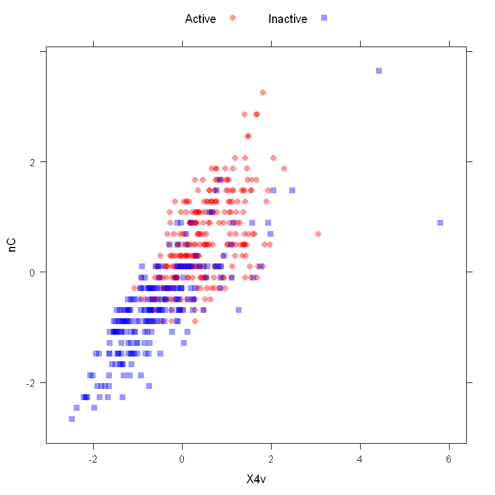

```r
plotSubset <- data.frame(scale(mdrrDescr[, c("nC", "X4v")]))
xyplot(nC ~ X4v,
       data = plotSubset,
       groups = mdrrClass,
       auto.key = list(columns = 2))
```

Después del spatial sign:

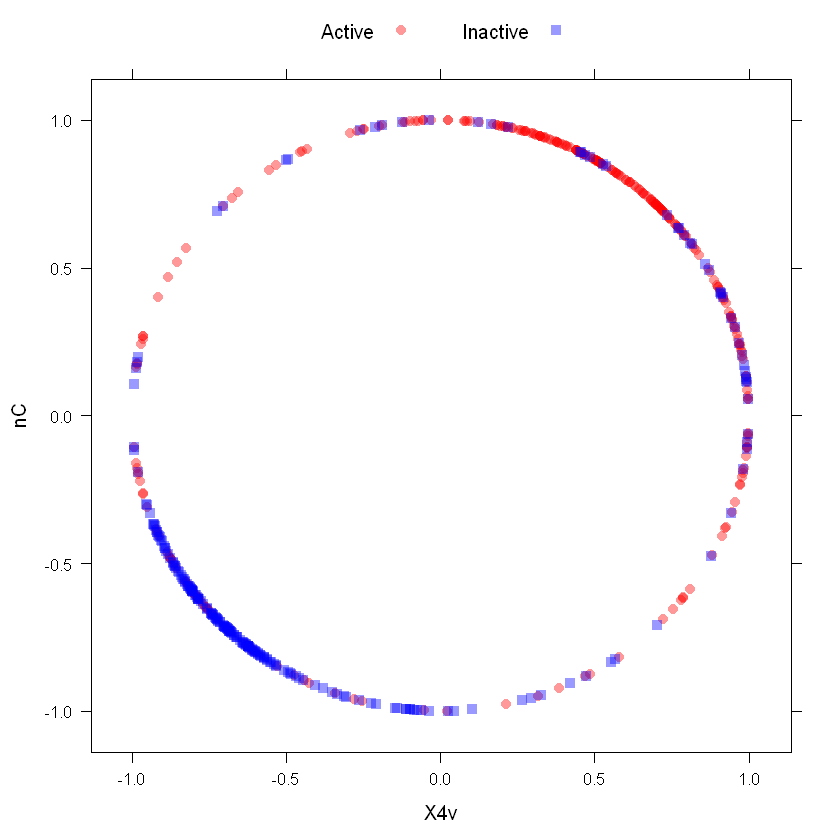

```r
transformed <- spatialSign(plotSubset)
transformed <- as.data.frame(transformed)
xyplot(nC ~ X4v,
       data = transformed,
       groups = mdrrClass,
       auto.key = list(columns = 2))
```

La opción "BoxCox"estimará una transformación Box-Cox en los predictores si los datos son mayores que cero.

```r
preProcValues2 <- preProcess(training, method = "BoxCox")
trainBC <- predict(preProcValues2, training)
testBC <- predict(preProcValues2, test)
preProcValues2
```

```
Created from 264 samples and 31 variables

Pre-processing:
  - Box-Cox transformation (31)
  - ignored (0)

Lambda estimates for Box-Cox transformation:
   Min. 1st Qu.  Median    Mean 3rd Qu.    Max.
-2.0000 -0.2500  0.5000  0.4387  2.0000  2.0000
```

## 7. Poniendo todo junto

En el modelo predictivo aplicado hay un estudio de caso en el que se predicen los tiempos de ejecución de los trabajos en un entorno informático de alto rendimiento. Los datos son:

```r
library(AppliedPredictiveModeling)
data(schedulingData)
str(schedulingData)
```

```
'data.frame':	4331 obs. of  8 variables:
 $ Protocol   : Factor w/ 14 levels "A","C","D","E",..: 4 4 4 4 4 4 4 4 4 4 ...
 $ Compounds  : num  997 97 101 93 100 100 105 98 101 95 ...
 $ InputFields: num  137 103 75 76 82 82 88 95 91 92 ...
 $ Iterations : num  20 20 10 20 20 20 20 20 20 20 ...
 $ NumPending : num  0 0 0 0 0 0 0 0 0 0 ...
 $ Hour       : num  14 13.8 13.8 10.1 10.4 ...
 $ Day        : Factor w/ 7 levels "Mon","Tue","Wed",..: 2 2 4 5 5 3 5 5 5 3 ...
 $ Class      : Factor w/ 4 levels "VF","F","M","L": 2 1 1 1 1 1 1 1 1 1 ...
```

Los datos son una mezcla de predictores categóricos y numéricos. Supongamos que queremos usar la transformación de Yeo-Johnson en los predictores continuos y luego centrarlos y escalarlos. Supongamos también que ejecutaremos modelos basados en árboles, por lo que es posible que deseemos mantener los factores como factores (en lugar de crear variables ficticias). Ejecutamos la función en todas las columnas excepto la última, que es el resultado.

```r
pp_hpc <- preProcess(schedulingData[, -8],
                     method = c("center", "scale", "YeoJohnson"))
pp_hpc
```

```
Created from 4331 samples and 7 variables

Pre-processing:
  - centered (5)
  - ignored (2)
  - scaled (5)
  - Yeo-Johnson transformation (5)

Lambda estimates for Yeo-Johnson transformation:
-0.08, -0.03, -1.05, -1.1, 1.44
```

```r
transformed <- predict(pp_hpc, newdata = schedulingData[, -8])
head(transformed)
```

| Protocol | Compounds | InputFields | Iterations | NumPending | Hour | Day |
| --- | --- | --- | --- | --- | --- | --- |
| E | 1.2289592 | -0.6324580 | -0.0615593 | -0.554123 | 0.004586516 | Tue |
| E | -0.6065826 | -0.8120473 | -0.0615593 | -0.554123 | -0.043733201 | Tue |
| E | -0.5719534 | -1.0131504 | -2.7894869 | -0.554123 | -0.034967177 | Thu |
| E | -0.6427737 | -1.0047277 | -0.0615593 | -0.554123 | -0.964170752 | Fri |
| E | -0.5804713 | -0.9564504 | -0.0615593 | -0.554123 | -0.902085020 | Fri |
| E | -0.5804713 | -0.9564504 | -0.0615593 | -0.554123 | 0.698108782 | Wed |

Los dos predictores etiquetados como "ignorados" en la salida son los predictores de dos factores. Estos no se modifican, pero los predictores numéricos se transforman. Sin embargo, el predictor del número de trabajos pendientes (NumPending) tiene una distribución muy escasa y desequilibrada:

```r
mean(schedulingData$NumPending == 0)
```

0.756176402678365

Para algunos otros modelos, esto podría ser un problema (especialmente si volvemos a muestrear o reducir la muestra de los datos). Podemos agregar un filtro para verificar predictores de varianza cero o casi cero antes de ejecutar los cálculos de preprocesamiento:

```r
pp_no_nzv <- preProcess(schedulingData[, -8],
                        method = c("center", "scale", "YeoJohnson", "nzv"))
pp_no_nzv
```

```
Created from 4331 samples and 7 variables

Pre-processing:
  - centered (4)
  - ignored (2)
  - removed (1)
  - scaled (4)
  - Yeo-Johnson transformation (4)

Lambda estimates for Yeo-Johnson transformation:
-0.08, -0.03, -1.05, 1.44
```

```r
predict(pp_no_nzv, newdata = schedulingData[1:6, -8])
```

| Protocol | Compounds | InputFields | Iterations | Hour | Day |
| --- | --- | --- | --- | --- | --- |
| E | 1.2289592 | -0.6324580 | -0.0615593 | 0.004586516 | Tue |
| E | -0.6065826 | -0.8120473 | -0.0615593 | -0.043733201 | Tue |
| E | -0.5719534 | -1.0131504 | -2.7894869 | -0.034967177 | Thu |
| E | -0.6427737 | -1.0047277 | -0.0615593 | -0.964170752 | Fri |
| E | -0.5804713 | -0.9564504 | -0.0615593 | -0.902085020 | Fri |
| E | -0.5804713 | -0.9564504 | -0.0615593 | 0.698108782 | Wed |

Tenga en cuenta que un predictor está etiquetado como "eliminado" y los datos procesados carecen del predictor eliminado.

## 8. Cálculos de distancia de clase

caret contiene funciones para generar nuevas variables predictoras basadas en distancias a centroides de clase (similar a cómo funciona el análisis discriminante lineal). Para cada nivel de una variable de factor, se calcula el centroide de clase y la matriz de covarianza. Para muestras nuevas, la distancia de Mahalanobis a cada uno de los centroides de clase se calcula y puede usarse como un predictor adicional. Esto puede ser útil para modelos no lineales cuando el verdadero límite de decisión es realmente lineal.

En los casos en que hay más predictores dentro de una clase que muestras, la classDistfunción tiene argumentos llamados pca y keep que permiten el análisis de componentes principales dentro de cada clase para evitar problemas con matrices de covarianza singulares.

predict.classDist se usa para generar las distancias de clase. De forma predeterminada, las distancias se registran, pero esto se puede cambiar mediante el argumento trans de predict.classDist.

```r
centroids <- classDist(trainBC, trainMDRR)
distances <- predict(centroids, testBC)
distances <- as.data.frame(distances)
head(distances)
```

|  | dist.Active | dist.Inactive |
| --- | --- | --- |
| ACEPROMAZINE | 3.787139 | 3.941234 |
| ACEPROMETAZINE | 4.306137 | 3.992772 |
| MESORIDAZINE | 3.707296 | 4.324115 |
| PERIMETAZINE | 4.079938 | 4.117170 |
| PROPERICIAZINE | 4.174101 | 4.430957 |
| DUOPERONE | 4.355328 | 6.000025 |

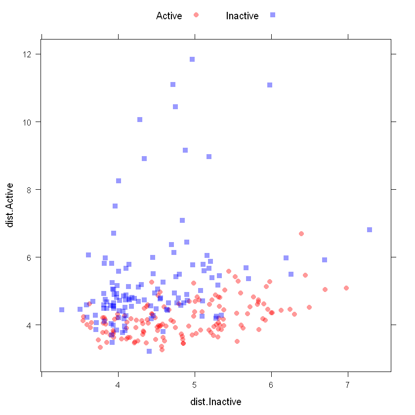

```r
xyplot(dist.Active ~ dist.Inactive,
       data = distances,
       groups = testMDRR,
       auto.key = list(columns = 2))
```